# Redtail Surfperch Recreational Fishery in Northern California

### Size Limit Implementation

#### Sampled Parameters

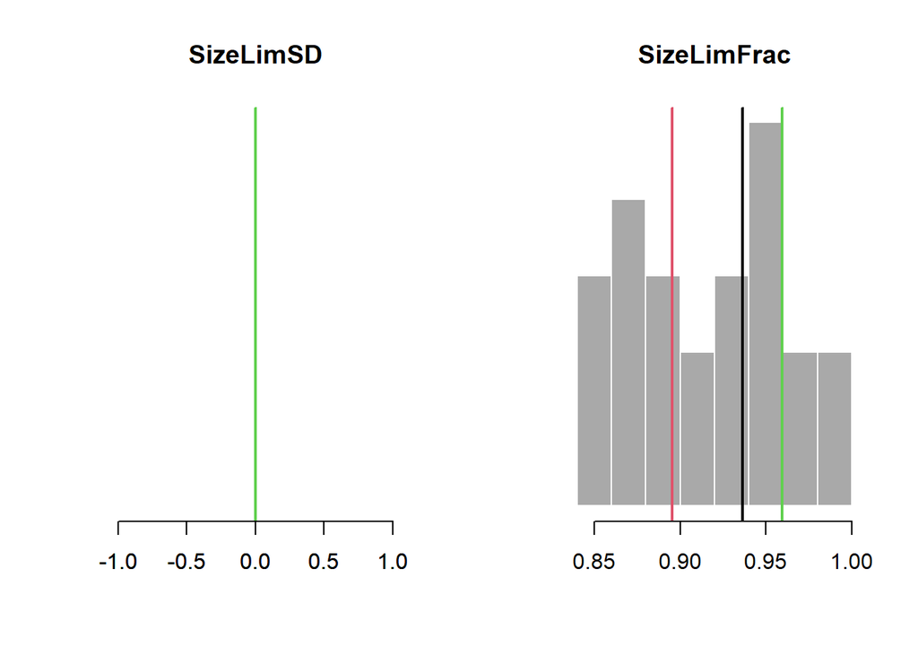

#### Time-Series

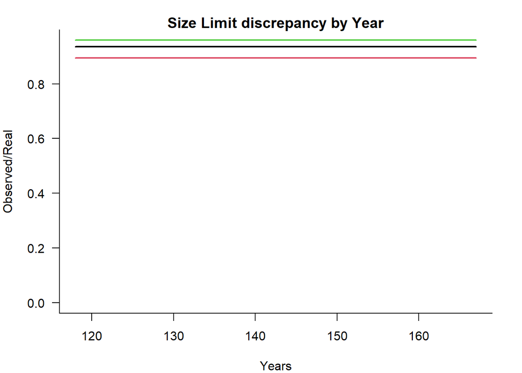

# Historical Simulation Plots

## Historical Time-Series

### Spawning Biomass

#### Depletion

Time-series plots of SB/SB0:

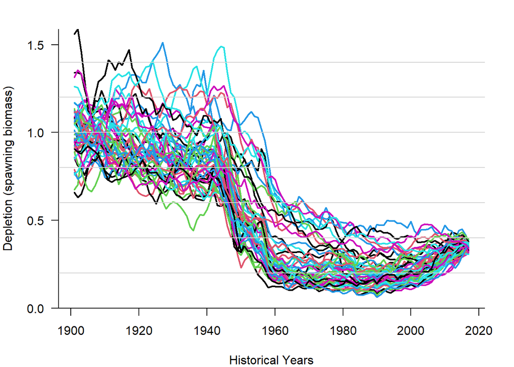

#### Absolute

Time-series plots of absolute SB:

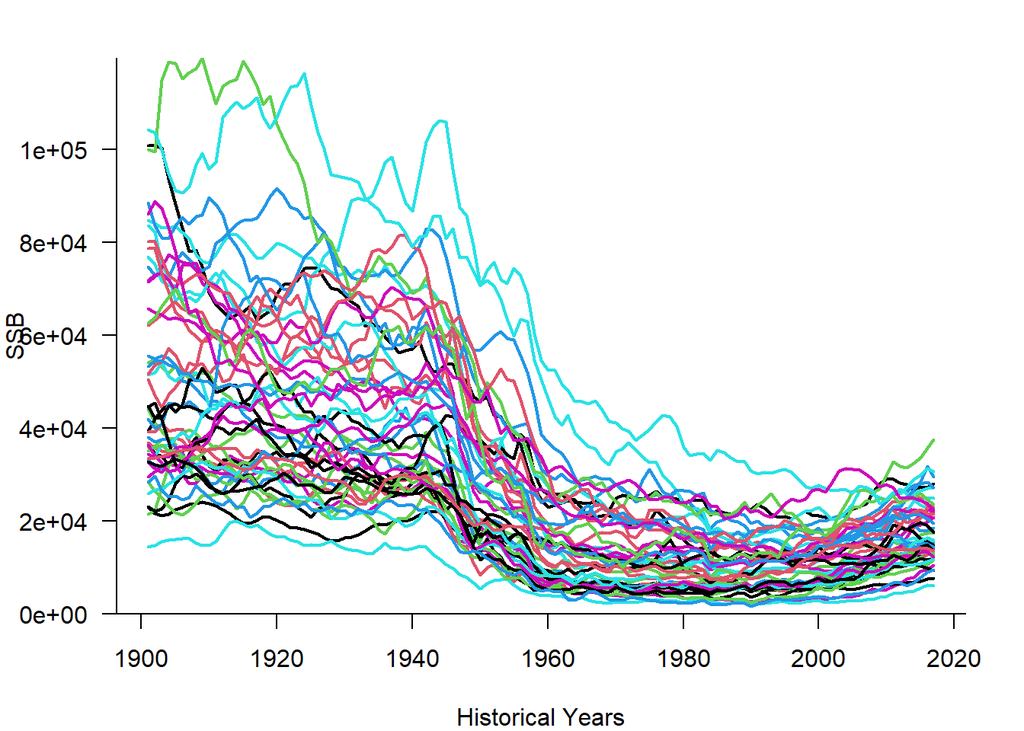

### Vulnerable Biomass

#### Depletion

Time-series plots of VB/VB0:

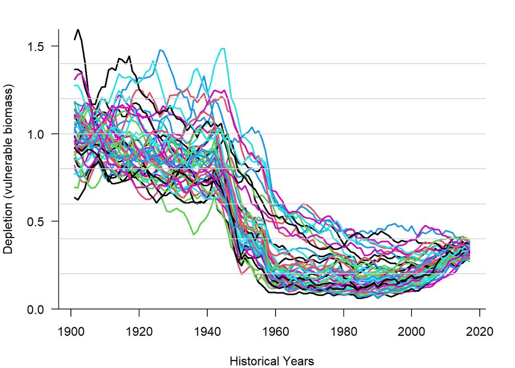

#### Absolute

Time-series plots of absolute VB:

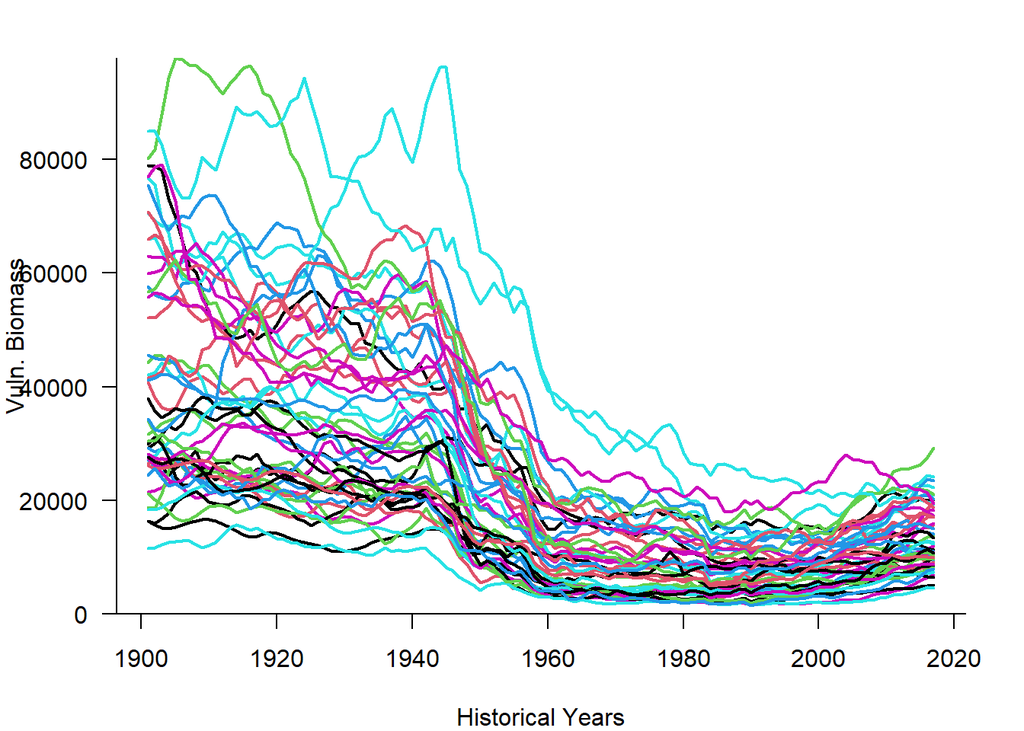

### Total Biomass

#### Depletion

Time-series plots of B/B0:

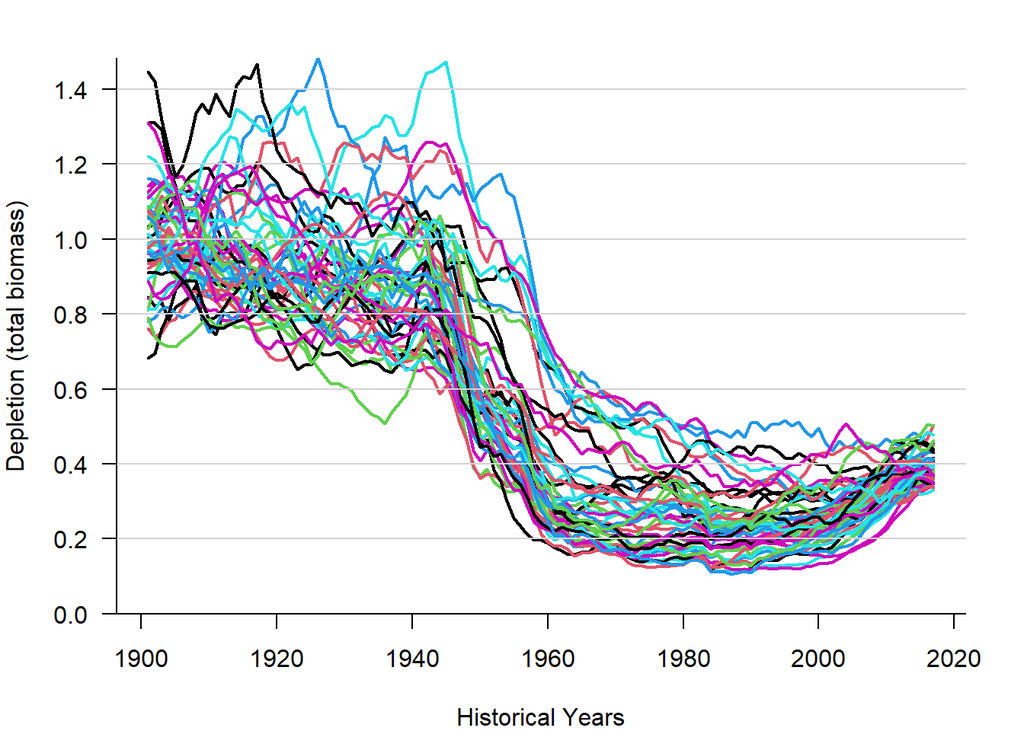

#### Absolute

Time-series plots of absolute B:

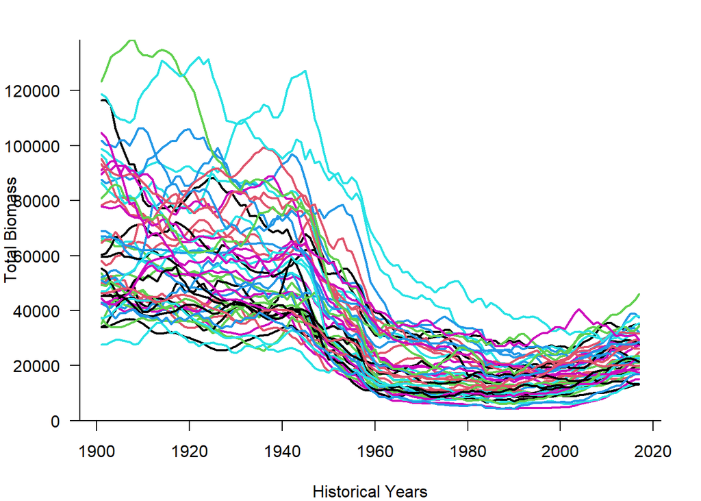

### Recruitment

#### Relative

Time-series plot of recruitment relative to R0:

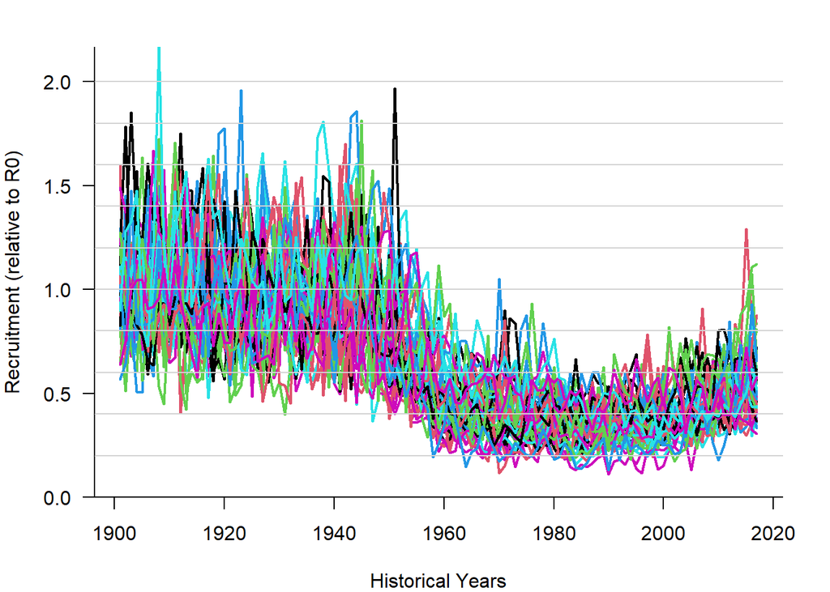

#### Absolute

Time-series plot of absolute recruitment:

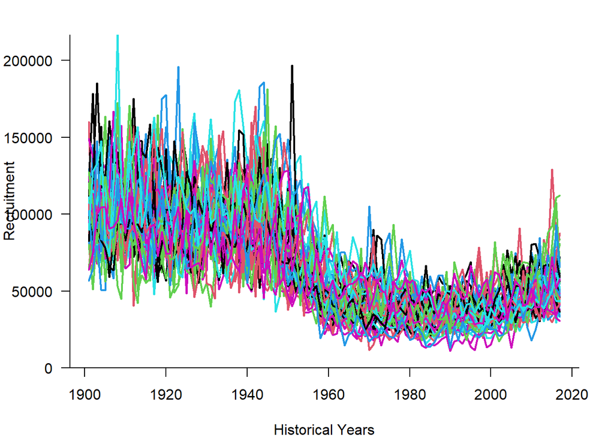

### Catch

#### Relative

Time-series of catch relative to the current year:

[figure not shown]

#### Absolute

Time-series of absolute catch:

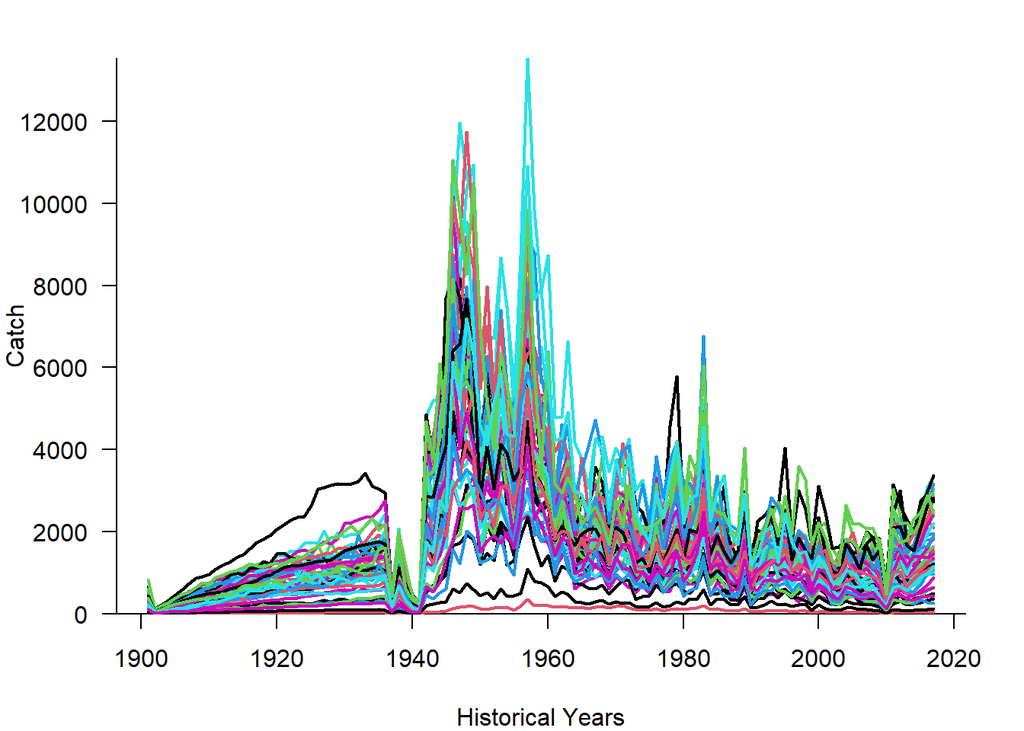

### Historical Fishing Mortality

#### Historical Time-Series

Time-series of historical fishing mortality:

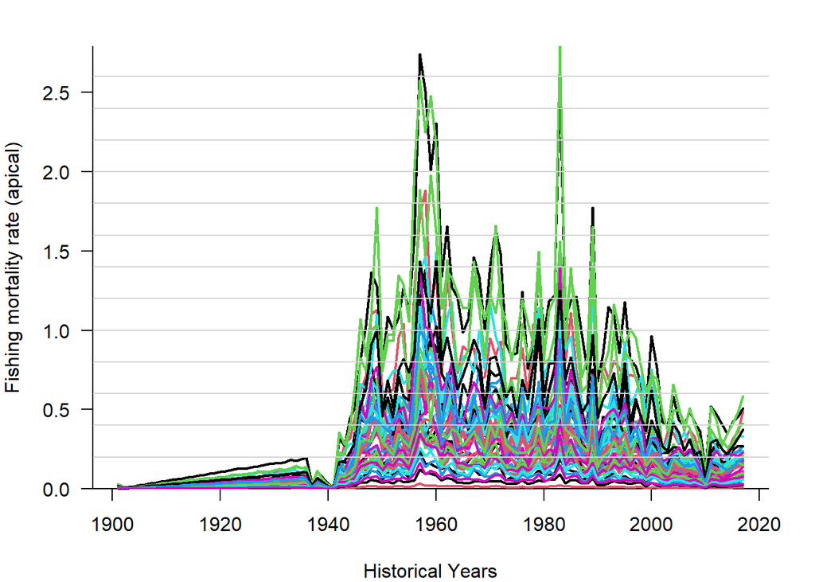

# References

Alverson, D. L. and M. J. Carney. 1975. A graphic review of the growth and decay of population cohorts. J. Cons. Int. Explor. Mer 36: 133-143.

Baltz DM. 1983. Life history variation among female surfperches (Perciformes: Embiotocidae). Env. Biol. Fish. Vol 10, 3:159-171.

Bennett DE, Wydoski RS. 1977. Biology of the Redtail Surfperch (Amphistichus rhodoterus) from the Central Oregon Coast. U.S. Fish Wildl. Serv. Tech. Pap. 90: 1-23.

Brookins K. 1995. Population dynamics and reproductive ecology of the redtail surfperch Amphistichus rhodoterus (Embiotocidae) [PhD dissertation]. Oregon State University. 213 p.

Carlisle JR., JG, Schott JW, Abramson NJ. 1960. The barred surfperch (Amphistichus argenteus Agassiz) in southern California. Calif. Fish Game, Fish Bull. 109: 1-79 p.

Carruthers TR, Punt AE, Walters CJ, MacCall A, McAllister MK, Dick EJ, Cope J. 2014. Evaluating methods for setting catch limits in data-limited fisheries. Fisheries Research 153:48-68.

Hoenig, J. M. 1983. Empirical use of longevity data to estimate mortality rates. Fish. Bull. 82: 898-903.

Hordyk A, Ono K, Valencia S, Loneragan N, Prince J. 2015. A novel length-based empirical estimation method of spawning potential ratio (SPR), and tests of its performance, for small-scale, data-poor fisheries. ICES Journal of Marine Science. 72(1):217-31.

Karpov KA, Albin DP, Van Buskirk WH. 1995. The marine recreational fishery in northern and central California. California Department of Fish and Game. Fish Bull. No 176: 1-192 p.

Ngoile M. 1978. Biology of the redtail surfperch, Amphistichus rhodoterus in northern California. M.S. Thesis. Humboldt State University, Arcata California. 56 p.

Pauly, D. 1980. On the interrelationships between natural mortality, growth parameters, and mean environmental temperature in 175 fish stocks. J. Cons. Int. Explor. Mer: 175-192.

Pruden D. 2000. Southern Oregon Surfperch Studies. Marine Resource Program. Oregon Fish and Wildlife. 25 p.

Then, A. Y., J. M. Hoenig, N. G. Hall, D. A. Hewitt. 2015. Evaluating the predictive performance of empirical estimators of natural mortality rate using information on over 200 fish species. ICES J. Mar. Sci. 72: 82-92.

Triplett EL. 1960. Notes on the life history of the barred surfperch, Amphistichus argenteus Agassiz, and a technique for culturing embiotocid embryos. Calif. Fish Game. 46:433-439.